# Smelting ingots with the furnace

We have the GUI, the work system, and the work component. We just need to tie everything together and code the smelting logic.

To start with, we have to set up groups and signals in `FurnaceEntity.tscn`.

Open the scene and assign the `FurnaceGUI` node to the `gui_entities` and `workers` group labels in the *Node* dock’s *Groups* tab.

Select the `GUIComponent` and assign `FurnaceGUI.tscn` to its *Gui Window* property.

Then, add a new script, `FurnaceEntity.gd`, attached to the root `FurnaceEntity` node, extending `Entity`.

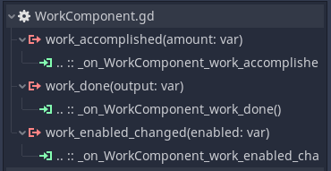

Then, connect the `GUIComponent`’s `gui_opened` and `gui_status_changed` signals to `FurnaceEntity`’s script,

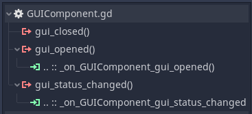

That should give you the following auto-generated script on `FurnaceEntity.gd`:

```
extends Entity


func _on_WorkComponent_work_enabled_changed(enabled) -> void:
    pass # Replace with function body.


func _on_WorkComponent_work_done(output) -> void:
    pass # Replace with function body.


func _on_WorkComponent_work_accomplished(amount) -> void:
    pass # Replace with function body.


func _on_GUIComponent_gui_status_changed() -> void:
    pass # Replace with function body.


func _on_GUIComponent_gui_opened() -> void:
    pass # Replace with function body.
```

And with that, we can begin scripting the logic.

## Scripting smelting

Let’s first go over the logic we need here.

When the user puts in both a valid fuel source and a valid ore, we want to set up the work component using a recipe, consume enough fuel to begin crafting, and consume a piece of ore to smelt.

When the crafting work completes, we need to instance the new blueprint and put it in the output slot.

Let’s jump in. We need to define properties and set the initial code layout for entities.

```
## Those are variables like in the Stirling engine.
var available_fuel := 0.0
var last_max_fuel := 0.0

onready var gui := $GUIComponent
onready var work := $WorkComponent
onready var animation := $AnimationPlayer


func _ready() -> void:
    # We don't plan on having different fuels cause different work speeds, so we
    # just set it to 100% speed all the time.
    work.work_speed = 1.0


## If smelting, displays the current recipe being smelted and how much time is
## left on the tooltip. Otherwise, display nothing.
func get_info() -> String:
    if work.is_enabled:
        return (
            "Smelting: %s into %s\nTime left: %ss"
            % [
                Library.get_entity_name_from(gui.gui.input),
                Library.get_entity_name_from(work.current_output),
                stepify(work.available_work, 0.1)
            ]
        )
    else:
        return ""
```

The information label will end up looking like this:

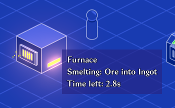

Most of the work for starting a job is inside the `_setup_work()` function.

It needs to compare fuel, input, and output and check for recipes before going ahead and enabling some work.

```
## Prepares the current job and consumes fuel, or aborts, depending on the
## inventory's state and available fuel.
func _setup_work() -> void:
    # If we have fuel in the inventory or fuel still in the tank, and we have
    # something in the input slot, and we aren't already busy with an existing
    # job
    if (gui.gui.fuel or available_fuel > 0.0) and gui.gui.input and work.available_work <= 0.0:

        # Get the input's name to provide it to the work component and try to
        # get an output name out of it.
        var input_id: String = Library.get_entity_name_from(gui.gui.input)

        # If the work component does find a job inside of the smelting recipe,
        # then we can enable work and consume fuel if needed.
        if work.setup_work({input_id: gui.gui.input.stack_count}, Recipes.Smelting):
            # We only enable work if there is nothing in the output. If there's
            # some coal we burnt out of wood in the way, we don't want to pour
            # metal on top and replace it. The user has to empty the output slot
            # first.
            #
            # Though we do allow it if the item that's in the output is the same
            # kind as the one we're about to craft.
            work.is_enabled = (
                not gui.gui.output_panel.held_item
                or (
                    Library.get_entity_name_from(work.current_output)
                    == Library.get_entity_name_from(gui.gui.output_panel.held_item)
                )
            )

            # We call the GUI's work function. This begins the animation
            # process.
            gui.gui.work(work.current_recipe.time)

            # If we're out of fuel in the gauge, we call `_consume_fuel()`,
            # which takes care of of consuming a piece to get energy from.
            if available_fuel <= 0.0:
                _consume_fuel(0.0)

    # If we're already working and we're out of things to smelt (no more input),
    elif work.available_work > 0.0 and not gui.gui.input:
        # Disable the work component and abort the GUI animation.
        work.available_work = 0.0
        work.is_enabled = false
        gui.gui.abort()

    # If we don't already have work and the other conditions have been skipped,
    # we disable the work component.
    #
    # It can happen that the worker is enabled at this point because we have
    # fuel but an input with no valid recipe.
    elif work.available_work <= 0.0:
        work.is_enabled = false
```

We introduce a couple of new functions and constants here that need to be implemented.

We start with `Recipes.Smelting`. This is a constant that lives in `Recipes.gd`.

It works like `Recipes.Crafting` dictionary, except used solely by machines that do smelting work.

So open up the `Recipes.gd` static class to add it.

```
## A dictionary of data for smelting machines. Keyed to the output name, with an
## inputs dictionary of input names with amounts and an amount of time it takes
## to craft.
const Smelting := {
    Ingot = {inputs = {"Ore": 1}, amount = 1, time = 5.0}
}
```

Back in `FurnaceEntity.gd`, the next function we encounter is `_consume_fuel()`.

This method is almost identical to `_consume_fuel()` on the `StirlingEngineEntity.gd` script, except that we don’t call `_setup_work()` again.

We’ve already called it before we got here, so instead, we just enable or disable the work component.

```
func _consume_fuel(amount: float) -> void:
    available_fuel = max(available_fuel - amount, 0.0)

    if available_fuel <= 0.0 and gui.gui.fuel:
        last_max_fuel = Recipes.Fuels[Library.get_entity_name_from(gui.gui.fuel)]
        available_fuel = last_max_fuel

        gui.gui.fuel.stack_count -= 1
        if gui.gui.fuel.stack_count == 0:
            gui.gui.fuel.queue_free()
            gui.gui.fuel = null

        gui.gui.update_labels()

    # If we have fuel, we enable the work component.
    work.is_enabled = available_fuel > 0.0
    gui.gui.set_fuel((available_fuel / last_max_fuel) if last_max_fuel > 0.0 else 0.0)
```

That gets our fuel and work going, and now we can move on to those signals.

Here are the first three.

```
## Whenever the user puts or removes something from the furnace's inventory,
## make sure that the current job is setup accordingly.
func _on_GUIComponent_gui_status_changed() -> void:
    _setup_work()


## Whenever the work component accomplishes any amount of work, consume some
## fuel from the fuel gauge.
func _on_WorkComponent_work_accomplished(amount: float) -> void:
    _consume_fuel(amount)
    Events.emit_signal("info_updated", self)


## When the job is finished, consume the requisite amount of inputs and grabs
## the output provided by the recipe into the output slot.
func _on_WorkComponent_work_done(output: BlueprintEntity) -> void:
    if _consume_input():
        gui.gui.grab_output(output)
        _setup_work()
    else:
        # If we failed to get the appropriate input, then get rid of the recipe
        # output we were going to craft and abort work until the situation is
        # fixed by the user.
        output.queue_free()
        work.is_enabled = false
    # Emitting `info_updated` keeps the tooltip up to date.
    Events.emit_signal("info_updated", self)
```

That brings us to a new function we need to implement: `_consume_input()`. Much like consuming fuel, it tries to take the recipe’s share out of the input stack.

```
## Attempts to consume the recipe's requisite items from the input stack.
## Returns `true` when it manages to, returns `false` if it failed to consume
## what it needed.
func _consume_input() -> bool:
    # If we have input items in the GUI, we first get the recipe's number of
    # items for this input.
    if gui.gui.input:
        var consumption_count: int = work.current_recipe.inputs[Library.get_entity_name_from(
            gui.gui.input
        )]

        # If we have enough, we reduce the stack and destroy it if it reaches `0`.
        if gui.gui.input.stack_count >= consumption_count:
            gui.gui.input.stack_count -= consumption_count
            if gui.gui.input.stack_count == 0:
                gui.gui.input.queue_free()
                gui.gui.input = null

            # Keep the labels up to date if any changes ocurred
            gui.gui.update_labels()

            # And we report success.
            return true
    else:
        # If we have no input and somehow still reached this point, make sure to
        # abort the animation. They may still be playing despite the job having
        # been stopped by `_setup_work()`.
        gui.gui.abort()

    # If we reach this branch, we either have no input, or we don't have enough
    # input.
    #
    # We return `false` so we don't consume anything but also don't provide any
    # output.
    return false
```

All that’s left are the two remaining signals.

When the work component becomes enabled, we need to play the work animation. When it becomes disabled, we want to play the shutdown animation.

When we open the inventory, if we’re still working, we also need to update the fuel gauge and make sure the arrow is moved to the correct spot.

```
## Plays the proper animation based on the new state of the work component.
func _on_WorkComponent_work_enabled_changed(enabled: bool) -> void:
    if enabled:
        animation.play("Work")
    else:
        animation.play("Shutdown")


## Updates the fuel gauge and progress bar arrow on the GUI
func _on_GUIComponent_gui_opened() -> void:
    gui.gui.set_fuel(available_fuel / last_max_fuel if last_max_fuel else 0.0)
    if work.is_enabled:
        # We call work to start the tween so it's properly configured.
        gui.gui.work(work.current_recipe.time)
        # With the tween running, we can seek to it. We can't seek with a tween
        # that's not running, after all.
        gui.gui.seek(work.current_recipe.time - work.available_work)
```

And that’s it!

Grab your axe and chop some lumber, grab your pickaxe and mine some ore, put down a furnace, open its GUI and put some lumber in one and ore in the other and reap your reward.

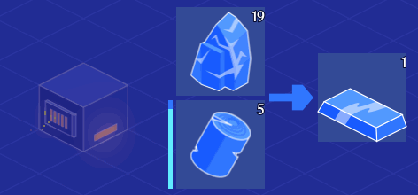

You’ve earned it.

## Coal

You’ll need a new blueprint entity and to edit the Recipes class, but you have everything else you need.

The main changes you’ll have to do are setting the *Item Filters* of the `FurnaceGUI`’s `InputInventoryBar` to both `Ore Lumber`.

You’ll also need to define a new recipe in `Recipes.Smelting` and to add `Coal` to the list of `Recipes.Fuels`.

```
const Smelting := {
    #...
    Coal = {inputs = {"Lumber": 1}, amount = 2, time = 3.0}
}
```

I’ll let you connect the dots as a little assignment. You should arrive at this result.

Below, I’m using already created coal to burn more wood, but you can split a lumber stack and put some in the upper slot and some in the fuel slot to make coal.

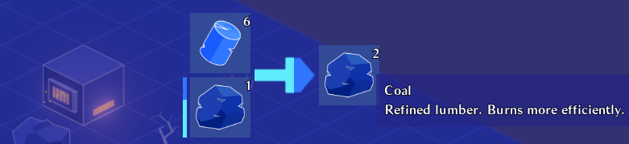

Having coal will allow you to test how having a crafted item in the output slot prevents you from crafting another kind until you took the output item.

## Code reference

`FurnaceEntity.gd`

```
extends Entity

var available_fuel := 0.0
var last_max_fuel := 0.0

onready var gui := $GUIComponent
onready var work := $WorkComponent
onready var animation := $AnimationPlayer


func _ready() -> void:
    work.work_speed = 1.0


func get_info() -> String:
    if work.is_enabled:
        return (
            "Smelting: %s into %s\nTime left: %ss"
            % [
                Library.get_entity_name_from(gui.gui.input),
                Library.get_entity_name_from(work.current_output),
                stepify(work.available_work, 0.1)
            ]
        )
    else:
        return ""


func _setup_work() -> void:
    if (gui.gui.fuel or available_fuel > 0.0) and gui.gui.input and work.available_work <= 0.0:

        var input_id: String = Library.get_entity_name_from(gui.gui.input)

        if work.setup_work({input_id: gui.gui.input.stack_count}, Recipes.Smelting):
            work.is_enabled = (
                not gui.gui.output_panel.held_item
                or (
                    Library.get_entity_name_from(work.current_output)
                    == Library.get_entity_name_from(gui.gui.output_panel.held_item)
                )
            )

            gui.gui.work(work.current_recipe.time)

            if available_fuel <= 0.0:
                _consume_fuel(0.0)

    elif work.available_work > 0.0 and not gui.gui.input:
        work.available_work = 0.0
        work.is_enabled = false
        gui.gui.abort()

    elif work.available_work <= 0.0:
        work.is_enabled = false


func _consume_fuel(amount: float) -> void:
    available_fuel = max(available_fuel - amount, 0.0)

    if available_fuel <= 0.0 and gui.gui.fuel:
        last_max_fuel = Recipes.Fuels[Library.get_entity_name_from(gui.gui.fuel)]
        available_fuel = last_max_fuel

        gui.gui.fuel.stack_count -= 1
        if gui.gui.fuel.stack_count == 0:
            gui.gui.fuel.queue_free()
            gui.gui.fuel = null

        gui.gui.update_labels()

    work.is_enabled = available_fuel > 0.0
    gui.gui.set_fuel((available_fuel / last_max_fuel) if last_max_fuel > 0.0 else 0.0)


func _on_GUIComponent_gui_status_changed() -> void:
    _setup_work()


func _on_WorkComponent_work_accomplished(amount: float) -> void:
    _consume_fuel(amount)
    Events.emit_signal("info_updated", self)


func _on_WorkComponent_work_done(output: BlueprintEntity) -> void:
    if _consume_input():
        gui.gui.grab_output(output)
        _setup_work()
    else:
        output.queue_free()
        work.is_enabled = false
    Events.emit_signal("info_updated", self)


func _consume_input() -> bool:
    if gui.gui.input:
        var consumption_count: int = work.current_recipe.inputs[Library.get_entity_name_from(
            gui.gui.input
        )]

        if gui.gui.input.stack_count >= consumption_count:
            gui.gui.input.stack_count -= consumption_count
            if gui.gui.input.stack_count == 0:
                gui.gui.input.queue_free()
                gui.gui.input = null

            gui.gui.update_labels()

            return true
    else:
        gui.gui.abort()

    return false


func _on_WorkComponent_work_enabled_changed(enabled: bool) -> void:
    if enabled:
        animation.play("Work")
    else:
        animation.play("Shutdown")


func _on_GUIComponent_gui_opened() -> void:
    gui.gui.set_fuel(available_fuel / last_max_fuel if last_max_fuel else 0.0)
    if work.is_enabled:
        gui.gui.work(work.current_recipe.time)
        gui.gui.seek(work.current_recipe.time - work.available_work)
```

Here’s the complete `Recipes.gd` script, with the coal recipe and fuel added.

```
class_name Recipes
extends Reference

const Crafting := {
    StirlingEngine = {inputs = {"Ingot": 8, "Wire": 3}, amount = 1},
    Wire = {inputs = {"Ingot": 2}, amount = 5},
    Battery = {inputs = {"Ingot": 12, "Wire": 5}, amount = 1},
    Pickaxe = {inputs = {"Branches": 2, "Ingot": 3}, amount = 1},
    CrudePickaxe = {inputs = {"Branches": 2, "Stone": 5}, amount = 1},
    Axe = {inputs = {"Branches": 2, "Ingot": 3}, amount = 1},
    CrudeAxe = {inputs = {"Branches": 2, "Stone": 5}, amount = 1},
    Branches = {inputs = {"Lumber": 1, "Axe": 0}, amount = 5},
    Chest = {inputs = {"Lumber": 2, "Branches": 3, "Ingot": 1}, amount = 1}
}

const Fuels := {Coal = 100, Lumber = 40.0, Branches = 10.0}
const Smelting := {
    Ingot = {inputs = {"Ore": 1}, amount = 1, time = 5.0},
    Coal = {inputs = {"Lumber": 1}, amount = 2, time = 3.0}
}
```